# R Notebook

`r`r library(caret)

`r`r library(tidyverse)

[output not shown]

`r`r library(AppliedPredictiveModeling) library(e1071) library(corrplot)

## Data

A database of 60 music performers has been prepared for the competition. The material is divided into six categories: classical music, jazz, blues, pop, rock and heavy metal. For each of the performers 15-20 music pieces have been collected. All music pieces are partitioned into 20 segments and parameterized. The descriptors used in parametrization also those formulated within the MPEG-7 standard, are only listed here since they have already been thoroughly reviewed and explained in many studies.

The feature vector consists of 191 parameters, the first 127 parameters are based on the MPEG-7 standard, the remaining ones are cepstral coefficients descriptors and time-related dedicated parameters:

1. parameter 1: Temporal Centroid,
2. parameter 2: Spectral Centroid average value,
3. parameter 3: Spectral Centroid variance,
4. parameters 4-37: Audio Spectrum Envelope (ASE) average values in 34 frequency bands
5. parameter 38: ASE average value (averaged for all frequency bands)
6. parameters 39-72: ASE variance values in 34 frequency bands
7. parameter 73: averaged ASE variance parameters
8. parameters 74,75: Audio Spectrum Centroid – average and variance values
9. parameters 76,77: Audio Spectrum Spread – average and variance values
10. parameters 78-101: Spectral Flatness Measure (SFM) average values for 24 frequency bands
11. parameter 102: SFM average value (averaged for all frequency bands)
12. parameters 103-126: Spectral Flatness Measure (SFM) variance values for 24 frequency bands
13. parameter 127: averaged SFM variance parameters
14. parameters 128-147: 20 first mel cepstral coefficients average values
15. parameters 148-167: the same as 128-147
16. parameters 168-191: dedicated parameters in time domain based of the analysis of the distribution of the envelope in relation to the rms value.

Column to predict: GENRE

`r`r train <- read_csv(/music/genresTrain.csv)

`r`r test <- read_csv(/music/genresTest.csv)

`r`r unique(train$GENRE)

```
[1] \Pop\       \Blues\     \Jazz\      \Classical\ \Rock\      \Metal\
```

The authors were confident about the amount of data on their hands so they created a massive test set.

## Data Splitting / Resampling

## Model Selection

As there is an absolutely massive number of features, classical statistical techniques such as linear regression are out of the picture. If regression techniques were to be used, dimensionality reduction should be performed using PCA, alternatively, penalised regression models such as Lasso, Ridge or Elastic Net could be used.

As the data is complex with no interpretability of individual variables, there is no incentive to favor a more interpretable model to a complex model.

Potential candidates:

- Random Forest
- SVM
- XGBoost

Boosted trees and support vector machines are very flexible models that have a very high likelyhood of producing the best results.

As a baseline, I would try Random Forest as it is the absolute most widely used industry standard algorithm. I would follow these up with Support Vector Machines and finally XGBoost, two models with very high flexibility and very low interpretability.

Machine learning is a very empirical science. XGBoost just seems to work very well across multiple problem domains. The winners of many Kaggle competitions used this model and mentioned: “When in doubt, use XGBoost”. The question is when is XGBoost not the best model?

## Exploration and Preprocessing

`r`r test_filled <- test %>% mutate(GENRE = NA) data <- rbind(train, test_filled)

colnames(data) <- tolower(colnames(data))

corrplot(cor(data[, -ncol(data)]), method = , tl.col = )

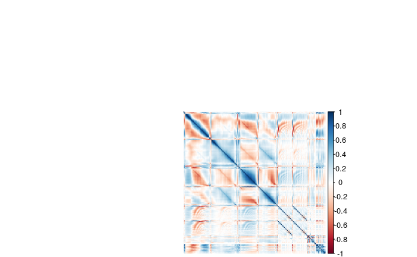

`r`r sum(is.na(data))

```
[1] 10269
```

There are no missing values in the data apart from the missing labels in the test set.

Judging by the correlation plots, there is going to be some heavy dimensionality reduction in order to remove correlated features.

`r`r findCorrelation(cor(data[, -ncol(data)]), cutoff = 0.75)

```
 [1]   5   6   7   8   9  13  14  15  16  17  24  27  28  29  32  73  83  85  86  87  88  89  90  91  92 102 114 116 117 118 119 123 128 148 170 175 180 181 184 186  10  11
[43]  25  30  33  34  39  40  41  42  43  44  45  65  66  67  68  93  94  95  96  97 120 121  71  23 129 130 131 132 133 134 135 136 137 138 139 140 141 142 143 144 145 146
[85] 147 178  76   2   3 182 187 183 189
```

`r`r length(findCorrelation(cor(data[, -ncol(data)]), cutoff = 0.75))

```
[1] 93
```

## Data Splitting

`r`r data <- data[, -]

[output not shown]

`r`r library(e1071) trans <- preProcess(data, method = c(, , , ))

[output not shown]

`r`r trans

```
Created from 22764 samples and 191 variables

Pre-processing:
  - Box-Cox transformation (101)
  - centered (191)
  - ignored (0)
  - principal component signal extraction (191)
  - scaled (191)

Lambda estimates for Box-Cox transformation:
   Min. 1st Qu.  Median    Mean 3rd Qu.    Max.
-0.6000  0.0000  0.4000  0.5376  1.0000  2.0000

PCA needed 72 components to capture 95 percent of the variance
```

```r
data_trans <- predict(trans, data)
train_trans <- data.frame(genre = labels_train, data_trans[1:nrow(train),])
test_trans <- data_trans[(nrow(train)+1):nrow(data_trans),]
```

`r`r ranf_fit <- train(genre ~ ., data = train_trans, method = , tuneLength = 1, trControl = trainControl(method = , number = 5, verboseIter = T))

This is taking absolutely forever. I’ll reduce the dimensionality in order to get a better computational time.

`r`r ranf_fit

```
Random Forest

12495 samples
   72 predictor
    6 classes: 'Blues', 'Classical', 'Jazz', 'Metal', 'Pop', 'Rock'

No pre-processing
Resampling: Cross-Validated (5 fold)
Summary of sample sizes: 9997, 9996, 9995, 9997, 9995
Resampling results:

  Accuracy   Kappa
  0.9113236  0.8892986

Tuning parameter 'mtry' was held constant at a value of 24
```

`r`r confusionMatrix(ranf_fit)

```
Cross-Validated (5 fold) Confusion Matrix

(entries are percentual average cell counts across resamples)

           Reference
Prediction  Blues Classical Jazz Metal  Pop Rock
  Blues      12.0       0.0  0.1   0.2  0.1  0.2
  Classical   0.2      26.3  2.5   0.0  0.2  0.1
  Jazz        0.3       1.2 21.0   0.3  0.3  1.0
  Metal       0.0       0.0  0.0   6.4  0.0  0.1
  Pop         0.1       0.0  0.1   0.1 11.6  0.4
  Rock        0.1       0.0  0.3   0.4  0.3 13.7

 Accuracy (average) : 0.9113
```

This is amazing accuracy. Maybe even human level. I’m quite happy with this.

```r
results <- predict(ranf_fit, test_trans)
```